# Front.Immunol.2024

Sagar Utturkar

August 2021

# Introduction:

## Publication: [PMID: 38384467](https://pubmed.ncbi.nlm.nih.gov/38384467/)

Zhang F, Huang B, Utturkar SM, Luo W, Cresswell G, Herr SA, Zheng S, Napoleon JV, Jiang R, Zhang B, Liu M, Lanman N, Srinivasarao M, Ratliff TL, Low PS. **Tumor-specific activation of folate receptor beta enables reprogramming of immune cells in the tumor microenvironment.** Front Immunol. 2024 Feb 7;15:1354735. doi: 10.3389/fimmu.2024.1354735. PMID: 38384467; PMCID: PMC10879311.

# Data Processing:

## Raw data processing through cell-ranger:

Processed raw data through Cell-Ranger.

```bash
cellranger count --id=G1-tumor \
--transcriptome=/reference/refdata-gex-mm10-2020-A \
--fastqs=/input/G1-tumor \
--sample=G1-tumor \
--localcores 32  \
--expect-cells=5000
```

## Import to Seurat:

```r
library(Seurat)
library(dplyr)
library(tidyverse)
library(knitr)
library(kableExtra)
library(ggplot2)
library(cowplot)
library(data.table)
library(dplyr)
library(RColorBrewer)

# import cell-ranger matrix
sample <- Read10X(data.dir = "/1_Cell_ranger/output/G1-tumor/outs/filtered_feature_bc_matrix")
sample <- CreateSeuratObject(counts = sample, project = "G1-tumor", min.cells = 3,
    min.features = 200)
```

# Quality Control:

Seurat allows to easily explore QC metrics and filter cells based on various quality criteria. A few commonly used QC metrics are given below:

1. Transcript (nCount) and gene (nFeature) abundance
   - Low-quality cells or empty droplets will often have very few genes/transcripts
   - Cell doublets or multiplets may exhibit an aberrantly high gene count
2. The percentage of reads that map to the mitochondrial genome
   - Low-quality / dying cells often exhibit extensive mitochondrial contamination
   - Mitochondrial QC metrics is calculated as percentage of counts originating from a set of mitochondrial genes (i.e. all genes starting with MT)
3. Ribosomal contents
   - Less than 50% ribosomal content is often preferred

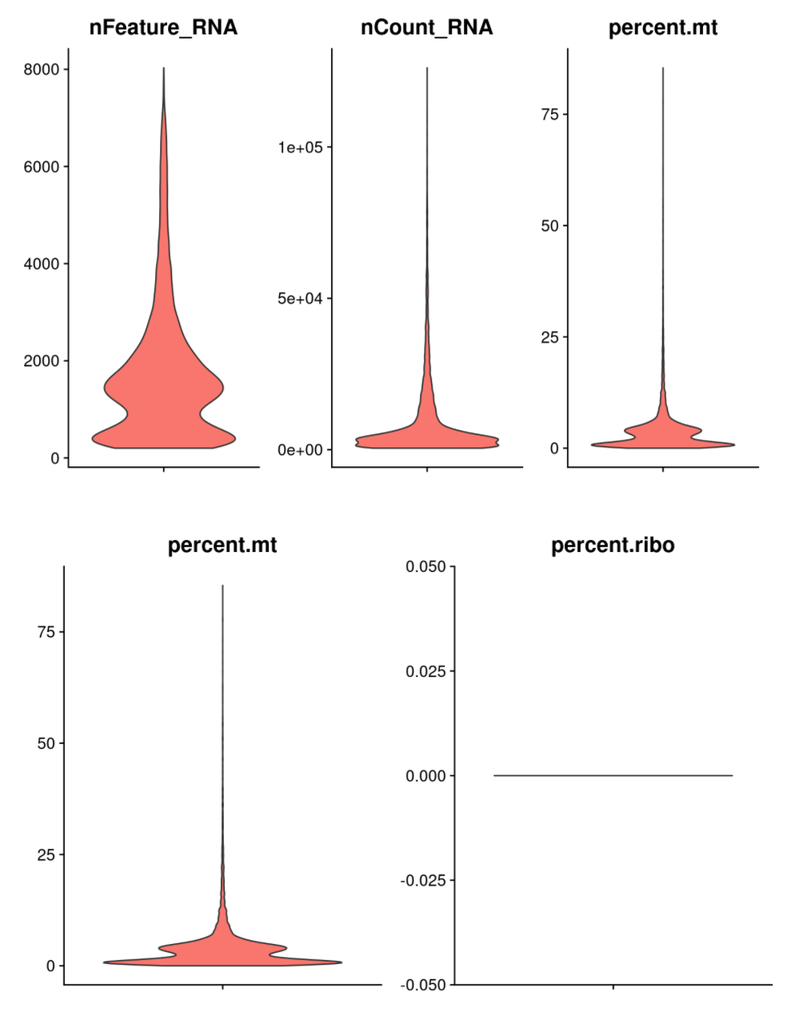

**Figure 1**

```r
VlnPlot(sample, features = c("nFeature_RNA", "nCount_RNA", "percent.mt"), ncol = 3,
    pt.size = 0)

VlnPlot(sample, features = c("percent.mt", "percent.ribo"), pt.size = 0)

FeatureScatter(object = sample, feature1 = "percent.mt", feature2 = "nCount_RNA",
    pt.size = 0.1, plot.cor = F)
```

[output not shown]